# MATH 253 Week 6 Exercises

Danny Kaplan

November 30, 2015

## Exercise ISLR 6.8.1

> We perform best subset, forward stepwise, and backward stepwise selection on a single data set. For each approach, we optain $p+1$ models, containing $0, 1, 2, \ldots, p$ predictors.
1. Which of the three models with $k$ predictors has the smallest *training* RSS? Best subset will never be worse than the other two, because best subset considers all of the models considered by the stepwise selection methods.
2. Which of the three models with $k$ predictors has the smallest *test* RSS? The answer could be considered to be the same as (a) on average. But for any particular testing set, either of the three might be best.
3. True or False:
   1. True. At $k+1$, forward selection has added a new predictor to those at $k$.
   2. True. At $k$, backward selection has deleted a predictor from those at $k+1$.
   3. False. The models at any $k$ for forward and backward selection do not necessarily have overlap.
   4. False. Same reason as in (3).
   5. False. Predictors used at $k$ may be completely different from predictors used at $k+1$.

## Exercise ISLR 6.8.2

## Exercise ISLR 6.8.9

Predict the number of applications received using the other variables in the `College` data set.

```r
model_formula <- Apps ~ .
library(ISLR)
data(College)
names(College)
```

```
##  [1] "Private"     "Apps"        "Accept"      "Enroll"      "Top10perc"
##  [6] "Top25perc"   "F.Undergrad" "P.Undergrad" "Outstate"    "Room.Board"
## [11] "Books"       "Personal"    "PhD"         "Terminal"    "S.F.Ratio"
## [16] "perc.alumni" "Expend"      "Grad.Rate"
```

```r
# log taken here!
College$Apps <- log10(College$Apps)
```

#### (a) Split the data into a training and a test data set.

```r
training_cases <- sample(1:nrow(College), size = nrow(College)/2)
Training <- College[training_cases, ]
Testing <- College[ - training_cases, ]
```

#### (b) Fit a linear model on the training set and evaluate the prediction error on the test set

```r
mod_b <- lm(model_formula, data=Training)
preds <- predict(mod_b, newdata = Testing)
mean((Testing$Apps - preds)^2)
```

```
## [1] 0.05459946
```

#### (c) Fit a ridge regression model

$\lambda$ is to be chosen by cross-validation.

```r
library(glmnet)

Training_MM <- model.matrix(model_formula, data = Training)
mod_c <- cv.glmnet(Training_MM , Training$Apps, alpha = 0)
mod_c$lambda.min
```

```
## [1] 0.04223861
```

```r
Testing_MM <- model.matrix(model_formula, data = Testing)
preds <- predict(mod_c, newx = Testing_MM, s = mod_c$lambda.min)
mean((Testing$Apps - preds)^2)
```

```
## [1] 0.05233864
```

#### (d) Fit a lasso regression model

Similar to (c), but with `alpha = 1`

```r
library(glmnet)
Training_MM <- model.matrix(model_formula, data = Training)
mod_d <- cv.glmnet(Training_MM , Training$Apps, alpha = 1)
mod_d$lambda.min
```

```
## [1] 0.0002715128
```

```r
Testing_MM <- model.matrix(model_formula, data = Testing)
preds <- predict(mod_d, newx = Testing_MM, s = mod_d$lambda.min)
mean((Testing$Apps - preds)^2)
```

```
## [1] 0.05436915
```

#### (e) Fit a PCR regression model

```r
library(pls)
```

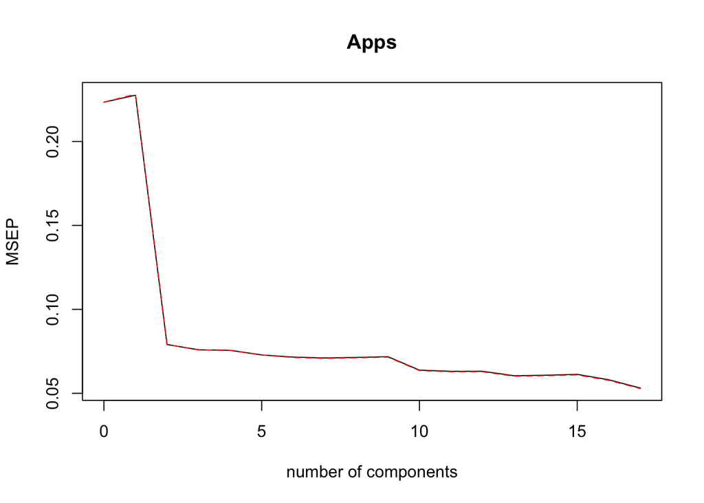

```r
mod_e <- pcr(model_formula, data = Training, validation = "CV")
validationplot(mod_e, val.type = "MSEP")
```

We’re going to choose 4 components:

```r
preds <- predict(mod_e,  newdata = Testing, ncomp = 4)
mean((Testing$Apps - preds)^2)
```

```
## [1] 0.07549043
```

#### (f) Fit a PLSR regression model

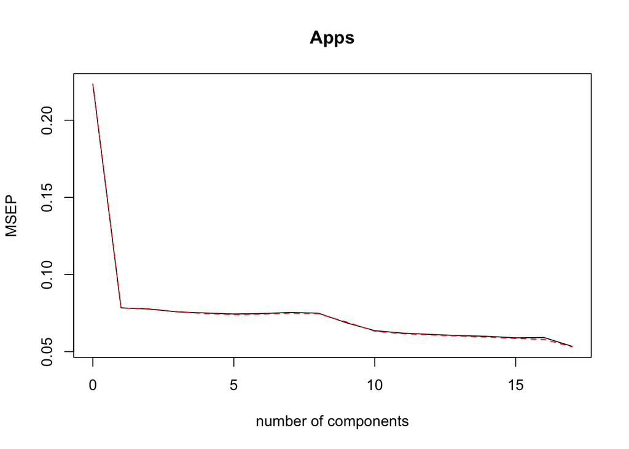

```r
library(pls)
mod_f <- plsr(model_formula, data = Training, validation = "CV")
validationplot(mod_f, val.type = "MSEP")
```

We’re going to choose 4 components:

```r
preds <- predict(mod_f,  newdata = Testing, ncomp = 4)
mean((Testing$Apps - preds)^2)
```

```
## [1] 0.07097459
```

#### (g) Comments

The mean square prediction error is about 140,000 for linear regression and for some of the of the other methods; the RMS prediction error is about 375 applications. The result varies considerably depending on what is selected for the `Training` set.

But there is a big outlier in `College$Apps`. It might be best to take the logarithm of the number of applications. When this is done (note the `log10(Apps)` right after the `names(College)` statement at the top of this report), the mean square prediction error (in log units) is about 0.05, or a root mean square error of $0.23$. This corresponds to an 95% confidence interval of 36% to 280%.